# Dashboards

Da pergunta de negócio ao painel publicado

Wesley Galvão

## Sobre esta aula

**SINESP: a violência caiu em 2026?**

Ao final da aula, você será capaz de:

1. desenhar um painel a partir de perguntas;
2. conhecer as famílias de ferramentas;
3. construir um painel com ajuda de IA.

Dataset: **SINESP** (Sistema Nacional de Informações de Segurança Pública), base VDE do Ministério da Justiça e Segurança Pública, 2025 e 2026, por UF e mês.

## O que é um dashboard

**Uma página que responde perguntas recorrentes, sempre com as mesmas estatísticas.** Não é relatório exploratório nem apresentação.

[figure not shown]

## Da pergunta ao gráfico

| Pergunta | Métrica | Comparação | Gráfico |
| --- | --- | --- | --- |
| Caiu ou subiu? | total no período | mesmo período do ano anterior | número grande + Δ% com seta |
| Onde é pior? | taxa por 100 mil hab. | entre UFs | mapa com cada estado pintado pela taxa (quanto mais escuro, maior) |
| Quais estados melhoraram ou pioraram? | taxa 2025 e 2026 | cada estado nos dois anos | *dumbbell*: dois pontos ligados por uma linha |
| Quando? | total mensal | mês a mês | linha, com rótulo direto |

Lembretes da aula de Fundamentos de Visualização: uma cor de destaque; barras começam no zero; sem arco-íris; rótulos diretos.

## Armadilha 1: períodos desiguais

**2026 só tem dados até setembro.**

[figure not shown]

## Armadilha 2: contagem não é risco

**Mapa de contagem mostra onde mora mais gente.**

[figure not shown]

## Ferramentas: um mapa

Pago

Gratuito

Sem código

[figure not shown]

Power BI

[figure not shown]

Tableau

[figure not shown]

Looker

[figure not shown]

Data Studio

Com código

—

[figure not shown]

Quarto

[figure not shown]

Dash

[figure not shown]

Streamlit

[figure not shown]

Apps Script

**Nesta disciplina: gratuitas + IA para gerar o código.**

## Pagas, sem código

- Power BI
- Tableau
- Looker

[figure not shown]

Exemplo de painel em Power BI. O [painel oficial do SINESP](https://app.powerbi.com/view?r=eyJrIjoiYThmMDBkNTYtOGU0Zi00MjUxLWJiMzAtZjFlMmYzYTgwOTBlIiwidCI6ImViMDkwNDIwLTQ0NGMtNDNmNy05MWYyLTRiOGRhNmJmZThlMSJ9) também é feito em Power BI, com os mesmos dados da aula.

- ✓ integra com Excel e o ecossistema Microsoft
- ✓ linguagem de medidas (DAX) poderosa
- ✗ compartilhar exige licença por usuário
- ✗ o editor desktop só roda no Windows

[figure not shown]

Tableau Agent: perguntas em linguagem natural sobre o painel. Galeria: https://public.tableau.com/app/discover/viz-of-the-day

- ✓ muita liberdade visual
- ✓ comunidade e galeria (Tableau Public)
- ✗ licença cara
- ✗ curva de aprendizado

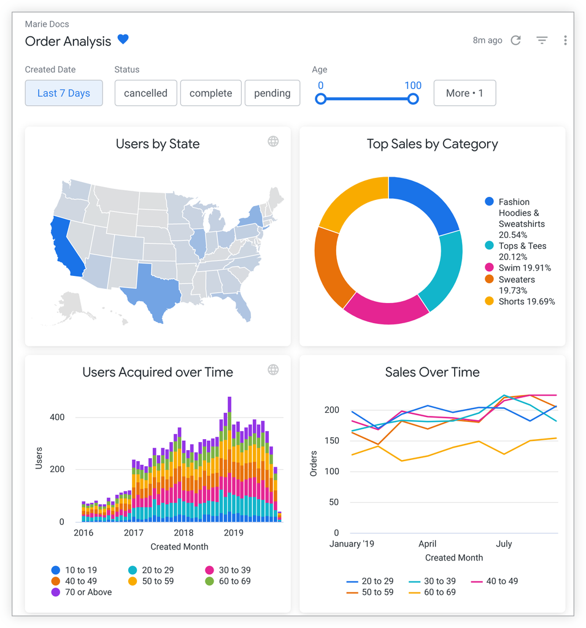

- ✓ métricas definidas uma vez para a empresa toda (LookML)
- ✓ governança
- ✗ exige modelagem e engenharia
- ✗ licença corporativa

## Data Studio (gratuito)

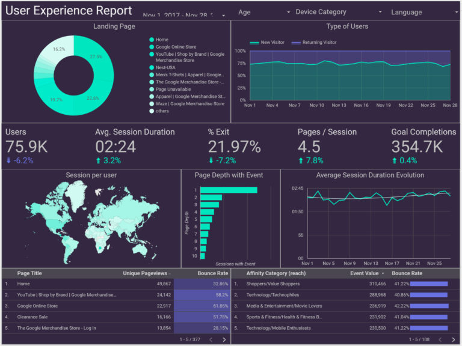

- ✓ gratuito
- ✓ conecta direto no Google Sheets e no BigQuery
- ✓ compartilha por link
- ✗ pouca personalização
- ✗ lento com bases grandes
- ✗ cálculos complexos são difíceis

Não confundir com o Looker, que é pago.

Demo 1: vamos montar ao vivo. Versão pronta: [relatório no Data Studio](https://datastudio.google.com/u/0/reporting/85b9d2f7-2787-4b8d-9b99-418b91406753/page/LQPDG)

## Com código: o mesmo painel em 4 ferramentas

- Quarto
- Dash
- Streamlit
- Apps Script

[figure not shown]

```javascript
viewof indicador = {
  const container = html`<div>...</div>`;
  container.addEventListener("change", (e) => {
    container.value = e.target.value; });
  return container;
}
```

Declarativo (Markdown + Python/OJS), HTML estático.

https://chcomin.github.io/curso-processamento-e-visualizacao-de-dados/M09_dashboards/paineis/quarto/painel.html

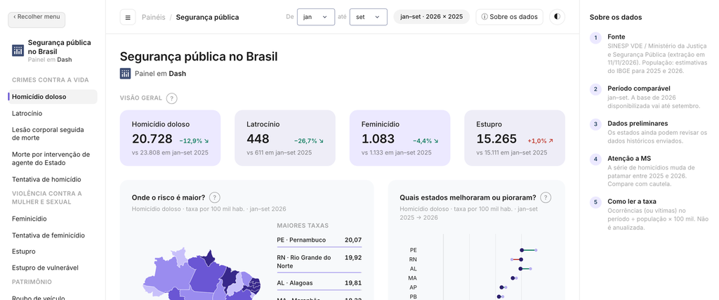

```python
@app.callback(
    Output("indicador-ativo", "data"),
    Input({"type": "item", "indicador": ALL}, "n_clicks"),
)
def atualizar_indicador(n_clicks_list): ...
```

Callbacks, controle total, precisa de servidor.

https://pvd-sinesp-dash.onrender.com

[figure not shown]

```python
indicador_selecionado = st.sidebar.radio(
    label="Indicador", options=TODOS_INDICADORES)
...
st.plotly_chart(fig_mapa, width="stretch")
```

Um script Python reativo, o mais rápido de escrever.

https://pvd-sinesp-streamlit.onrender.com

[figure not shown]

```javascript
function servidor(funcao, arg) {
  return new Promise((ok, falha) => {
    google.script.run.withSuccessHandler(ok)
      .withFailureHandler(falha)[funcao](arg);
  });
}
```

HTML/JS dentro do Google, publica com 1 clique.

https://script.google.com/macros/s/AKfycbzveUVAHfTnYVZ4SKn-_aNEEPKepW6r3ztBLYDpJYuczfJ3FbS5ugmicIJs2Qw5B2YVFg/exec

## Comparativo

| Ferramenta | Código | Custo | Hospedagem | Customização | Bom para |
| --- | --- | --- | --- | --- | --- |
| Power BI | não | pago | nuvem Microsoft | média | empresas no ecossistema Microsoft |
| Tableau | não | pago | Tableau Cloud / Public | alta (visual) | exploração e galeria visual |
| Looker | LookML | pago | Google Cloud | média | métricas governadas |
| Data Studio | não | grátis | Google | baixa | painel rápido sobre Sheets/BigQuery |
| Quarto | Markdown + Python/OJS | grátis | estático (GitHub Pages) | alta | painel publicado como página |
| Dash | Python | grátis | servidor | muito alta | aplicação com controle total |
| Streamlit | Python | grátis | servidor | média | protótipo rápido |
| Apps Script | HTML/JS | grátis | Google (1 clique) | alta | painel sobre Google Sheets |

Muita customização = muito código → é aí que a IA ajuda.

## IA como assistente

[figure not shown]

Skill `pvd-dashboard-apps-script-demo`: pergunta as especificações → gera → confere → publica (Claude Code, Gemini CLI, Antigravity).

Demo 2: Apps Script com a skill.

## O que é uma skill

**Uma pasta com um arquivo de texto, `SKILL.md`, que ensina um agente de IA a fazer uma tarefa.**

- O agente lê só o `name` e a `description` (é barato); se o pedido combina, carrega o resto.
- Dentro: quando usar, passos, perguntas ao usuário, regras e modelos de código.
- É texto: qualquer pessoa escreve e revisa.
- O mesmo arquivo funciona no Claude Code, Gemini CLI, Antigravity e Codex.

Claude Code: `~/.claude/skills/pvd-dashboard-apps-script-demo/SKILL.md`  
Gemini CLI: `gemini skills install <pasta>`  
Antigravity: `~/.gemini/antigravity/skills/`  
Sem agente? Cole o `SKILL.md` num chat.

## Anatomia de uma skill

```markdown
---
name: pvd-dashboard-apps-script-demo
description: Monta um painel de uma página em Apps Script a partir de
  uma planilha. Use quando pedirem um dashboard sobre um Google Sheets.
---
# Painel de uma página em Apps Script

## 1. Ler os dados
Cabeçalho e 5 linhas: qual coluna é tempo, grupo, valor?

## 2. Perguntar ao usuário (uma rodada)
Recorte · 1 ou 2 perguntas · "menor é melhor?" · quem acessa

## 3. Confirmar o plano → 4. Gerar
Cada pergunta vira um gráfico. Copie os modelos, mude só o CONFIG.

## 5. Conferir → 6. Publicar
A tabela dinâmica bate com o painel? Implantar → App da Web.

## Regras de visual · Modelos: Code.gs, Index.html, appsscript.json
```

Uma skill é um procedimento escrito: o que perguntar, o que gerar e como conferir.

## Demo: o painel que vamos montar

**Roubo de veículos no Sudeste**De [jan ▾] até [set ▾]

P1. O roubo de veículos caiu em 2026?

total mensal, 2026 × 2025

P2. Em qual estado o risco é maior?

taxa por 100 mil hab. por UF; cinza = Sudeste

O filtro de meses vale para os dois anos: compara sempre o mesmo período.

## Demo: o mesmo painel, duas vezes

**Data Studio (à mão)**

1. conectar a planilha
2. filtro do recorte
3. controle de período com comparação “ano anterior”
4. série temporal, barras e tabela

**Apps Script (com a skill)**

> Use a skill pvd-dashboard-apps-script-demo com a planilha <link>, aba `dados`. Recorte: roubo de veículo no Sudeste. Perguntas: o roubo de veículos caiu em 2026? Em qual estado o risco é maior?

O agente pergunta → confirma o plano → gera 3 arquivos → publica.

Nos dois casos, confira: a tabela do painel tem que bater com a tabela dinâmica do Sheets.

## Links

- Painel em Apps Script: https://script.google.com/macros/s/AKfycbzveUVAHfTnYVZ4SKn-_aNEEPKepW6r3ztBLYDpJYuczfJ3FbS5ugmicIJs2Qw5B2YVFg/exec
- Painel demo (Apps Script): https://script.google.com/macros/s/AKfycbyYcm5ri3rYiCCNoywzPp5dMYOQovQUoHIvLh8FvsGpIIqiB3na1EWiuGxaG-M6AWDW/exec
- Painel em Quarto: https://chcomin.github.io/curso-processamento-e-visualizacao-de-dados/M09_dashboards/paineis/quarto/painel.html
- Painel em Dash: https://pvd-sinesp-dash.onrender.com
- Painel em Streamlit: https://pvd-sinesp-streamlit.onrender.com
- Código, dados e skill: https://github.com/chcomin/curso-processamento-e-visualizacao-de-dados/tree/main/M09_dashboards
- Skill da aula (1 arquivo): https://github.com/chcomin/curso-processamento-e-visualizacao-de-dados/blob/main/M09_dashboards/app_script/pvd-dashboard-apps-script-demo/SKILL.md
- Painel demo (Data Studio): https://datastudio.google.com/u/0/reporting/85b9d2f7-2787-4b8d-9b99-418b91406753/page/LQPDG
- [Planilha pública (Google Sheets, UF mensal)](https://docs.google.com/spreadsheets/d/1tiSt45GO9qlWjm3iWxpkVTlcULahEdxPmdpDLYzLIRg/edit?usp=sharing)
- [Painel oficial do SINESP (Power BI)](https://app.powerbi.com/view?r=eyJrIjoiYThmMDBkNTYtOGU0Zi00MjUxLWJiMzAtZjFlMmYzYTgwOTBlIiwidCI6ImViMDkwNDIwLTQ0NGMtNDNmNy05MWYyLTRiOGRhNmJmZThlMSJ9)